# Final Group project

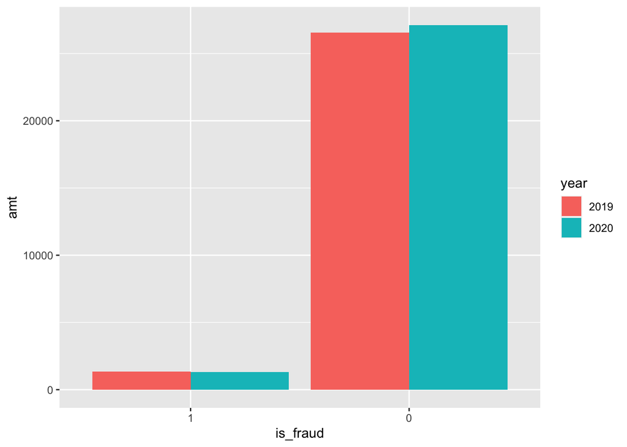

```r
# assess whether there's significant difference between amount of fraud in 2019 vs. 2020
card_fraud %>%
  group_by(is_fraud,year) %>%
  summarise(amt) %>%
  mutate(year = as.factor(year)) %>%
  ggplot(aes(x = is_fraud, y = amt, fill = year)) +
  geom_bar(stat = "identity", position = "dodge")
```

[figure not shown]

```r
# doesn't seem to be a difference between the years


# assess fraud by state

card_fraud %>%
  group_by(is_fraud,state) %>%
  summarise(total=n()) %>%
  filter(is_fraud == 1) %>%
  arrange(desc(total)) %>%
  ggplot(aes(x = reorder(state, -total), y = total)) +
  geom_bar(stat = "identity", fill="blue") +
  geom_text(aes(label=total),position=position_stack(vjust=0.5)) +
  xlab("State") +
  ylab("Incidents of Fraud") +
  ggtitle("Top 10 States for Fraud (2019-2020)") +
  theme_minimal()
```

[figure not shown]

```r
# assess fraud by category
card_fraud %>%
  group_by(is_fraud,category) %>%
  summarise(total=n()) %>%
  filter(is_fraud == 1) %>%
  arrange(desc(total)) %>%
  ggplot(aes(x = reorder(category, -total), y = total)) +
  geom_bar(stat = "identity", fill="blue") +
  geom_text(aes(label=total),position=position_stack(vjust=0.5)) +
  xlab("State") +
  ylab("Category") +
  ggtitle("Top 5 Categories for Fraud (2019-2020)") +
  theme_minimal()
```

Strings are usually not a useful format for classification problems. The strings should be converted to factors, dropped, or otherwise transformed.

*Strings to Factors*

- `category`, Category of Merchant
- `job`, Job of Credit Card Holder

```r
card_fraud <- card_fraud %>%
  mutate(category = as.factor(category)) %>%
  mutate(job = as.factor(job))

class(card_fraud$category)
```

```
## [1] "factor"
```

*Strings to Geospatial Data*

We have plenty of geospatial data as lat/long pairs, so I want to convert city/state to lat/long so I can compare to the other geospatial variables. This will also make it easier to compute new variables like the distance the transaction is from the home location.

- `city`, City of Credit Card Holder
- `state`, State of Credit Card Holder

```r
# did not end up needing this data

#city_geo <- card_fraud %>%
 #distinct(city, state) %>%
  #geocode(
   #city = city,
    #state = state,
    #method = "osm",
    #lat = "city_lat",
    #long = "city_long")
```

## 2.3 Exploring factors: how is the compactness of categories?

- Do we have excessive number of categories? Do we want to combine some?

```r
card_fraud %>%
  count(category, sort=TRUE)%>%
  mutate(perc = n/sum(n))
```

```
## # A tibble: 14 × 3
##    category           n   perc
##    <fct>          <int>  <dbl>
##  1 gas_transport  68046 0.101
##  2 grocery_pos    63791 0.0951
##  3 home           63597 0.0948
##  4 shopping_pos   60416 0.0900
##  5 kids_pets      58772 0.0876
##  6 shopping_net   50743 0.0756
##  7 entertainment  48521 0.0723
##  8 food_dining    47527 0.0708
##  9 personal_care  46843 0.0698
## 10 health_fitness 44341 0.0661
## 11 misc_pos       41244 0.0615
## 12 misc_net       32829 0.0489
## 13 grocery_net    23485 0.0350
## 14 travel         20873 0.0311
```

```r
card_fraud %>%
  count(job, sort=TRUE) %>%
  mutate(perc = n/sum(n))
```

```
## # A tibble: 494 × 3
##    job                            n    perc
##    <fct>                      <int>   <dbl>
##  1 Film/video editor           5106 0.00761
##  2 Exhibition designer         4728 0.00705
##  3 Naval architect             4546 0.00677
##  4 Surveyor, land/geomatics    4448 0.00663
##  5 Materials engineer          4292 0.00640
##  6 Designer, ceramics/pottery  4262 0.00635
##  7 IT trainer                  4014 0.00598
##  8 Financial adviser           3959 0.00590
##  9 Systems developer           3948 0.00588
## 10 Environmental consultant    3831 0.00571
## # ℹ 484 more rows
```

The predictors `category` and `job` are transformed into factors.

```r
card_fraud <- card_fraud %>%
  mutate(category = factor(category),
         job = factor(job))
```

`category` has 14 unique values, and `job` has 494 unique values. The dataset is quite large, with over 670K records, so these variables don’t have an excessive number of levels at first glance. However, it is worth seeing if we can compact the levels to a smaller number.

### 2.3.1 Why do we care about the number of categories and whether they are “excessive”?

Consider the extreme case where a dataset had categories that only contained one record each. There is simply insufficient data to make correct predictions using category as a predictor on new data with that category label. Additionally, if your modeling uses dummy variables, having an extremely large number of categories will lead to the production of a huge number of predictors, which can slow down the fitting. This is fine if all the predictors are useful, but if they aren’t useful (as in the case of having only one record for a category), trimming them will improve the speed and quality of the data fitting.

If I had subject matter expertise, I could manually combine categories. If you don’t have subject matter expertise, or if performing this task would be too labor intensive, then you can use cutoffs based on the amount of data in a category. If the majority of the data exists in only a few categories, then it might be reasonable to keep those categories and lump everything else in an “other” category or perhaps even drop the data points in smaller categories.

## 2.4 Do all variables have sensible types?

Consider each variable and decide whether to keep, transform, or drop it. This is a mixture of Exploratory Data Analysis and Feature Engineering, but it’s helpful to do some simple feature engineering as you explore the data. In this project, we have all data to begin with, so any transformations will be performed on the entire dataset. Ideally, do the transformations as a `recipe_step()` in the tidymodels framework. Then the transformations would be applied to any data the recipe was used on as part of the modeling workflow. There is less chance of data leakage or missing a step when you perform the feature engineering in the recipe.

## 2.5 Which variables to keep in your model?

You have a number of variables and you have to decide which ones to use in your model. For instance, you have the latitude/lognitude of the customer, that of the merchant, the same data in radians, as well as the `distance_km` and `distance_miles`. Do you need them all?

## 2.6 Fit your workflows in smaller sample

You will be running a series of different models, along the lines of the California housing example we have seen in class. However, this dataset has 670K rows and if you try various models and run cross validation on them, your computer may slow down or crash.

```r
# select a smaller subset
my_card_fraud <- card_fraud %>%
  # focus on relevant variables
  select(is_fraud, amt, distance_km, hour, wday, month_name, age, category) %>%
  # select a smaller subset, 5% of the entire dataframe
  slice_sample(prop = 0.05)
```

```r
# **Split the data**

set.seed(123)

data_split <- initial_split(my_card_fraud, # updated data
                           prop = 0.8,
                           strata = is_fraud)

card_fraud_train <- training(data_split)
# card_fraud_is_fraud <- is_frauding(data_split)
```

## 2.8 Cross Validation

Start with 3 CV folds to quickly get an estimate for the best model and you can increase the number of folds to 5 or 10 later.

```r
set.seed(123)
cv_folds <- vfold_cv(data = card_fraud_train,
                          v = 3,
                          strata = is_fraud)
cv_folds
```

```
## #  3-fold cross-validation using stratification
## # A tibble: 3 × 2
##   splits               id
##   <list>               <chr>
## 1 <split [17893/8947]> Fold1
## 2 <split [17893/8947]> Fold2
## 3 <split [17894/8946]> Fold3
```

## 2.9 Define a tidymodels `recipe`

What steps are you going to add to your recipe? Do you need to do any log transformations?

```r
fraud_rec <- recipe(is_fraud ~ ., data = card_fraud_train) %>%
  # Transforms data to remove right-skewed variables
  step_log(amt, distance_km, age) %>%
  step_naomit(everything(), skip = TRUE) %>%
  step_novel(all_nominal(), -all_outcomes()) %>%
  step_normalize(all_numeric(), -all_outcomes()) %>%
  step_dummy(all_nominal(), -all_outcomes()) %>%
  step_zv(all_numeric(), -all_outcomes())
```

Once you have your recipe, you can check the pre-processed dataframe

```r
prepped_data <-
  fraud_rec %>% # use the recipe object
  prep() %>% # perform the recipe on training data
  juice() # extract only the preprocessed dataframe

glimpse(prepped_data)
```

```
## Rows: 26,840
## Columns: 37
## $ amt                     <dbl> 1.04907763, -1.42604735, 0.61518782, -1.298118…
## $ distance_km             <dbl> -3.85676150, 0.11981008, 0.45349650, 1.3684827…
## $ hour                    <dbl> -0.53680474, 1.06968087, -0.53680474, 0.923636…
## $ age                     <dbl> -0.18303002, 0.22193157, 0.18415800, -0.548233…
## $ is_fraud                <fct> 0, 0, 0, 0, 0, 0, 0, 0, 0, 0, 0, 0, 0, 0, 0, 0…
## $ wday_1                  <dbl> -0.54006172, 0.23145502, -0.23145502, 0.077151…
## $ wday_2                  <dbl> 0.54006172, -0.23145502, -0.23145502, -0.38575…
## $ wday_3                  <dbl> -0.4308202, -0.4308202, 0.4308202, -0.1846372,…
## $ wday_4                  <dbl> 0.2820380, -0.1208734, -0.1208734, 0.3626203, …
## $ wday_5                  <dbl> -0.1497862, 0.3637664, -0.3637664, 0.3209704, …
## $ wday_6                  <dbl> 0.06154575, 0.55391171, 0.55391171, -0.3077287…
## $ wday_7                  <dbl> -0.01706972, 0.35846409, -0.35846409, -0.59744…
## $ month_name_01           <dbl> -0.222374794998330349571347, 0.370624658330550…
```

[output cut: 24 more lines]

## 2.10 Define various models

You should define the following classification models:

1. Logistic regression, using the `glm` engine
2. Decision tree, using the `C5.0` engine
3. Random Forest, using the `ranger` engine and setting `importance = "impurity"`)
4. A boosted tree using Extreme Gradient Boosting, and the `xgboost` engine
5. A k-nearest neighbours, using 4 nearest_neighbors and the `kknn` engine

```r
## Model Building

# 1. Pick a `model type`
# 2. set the `engine`
# 3. Set the `mode`:  classification

# Logistic regression
log_spec <-  logistic_reg() %>%  # model type
  set_engine(engine = "glm") %>%  # model engine
  set_mode("classification") # model mode

# Show your model specification
log_spec
```

```
## Logistic Regression Model Specification (classification)
##
## Computational engine: glm
```

```r
# Decision Tree
tree_spec <- decision_tree() %>%
  set_engine(engine = "C5.0") %>%
  set_mode("classification")

tree_spec
```

```
## Decision Tree Model Specification (classification)
##
## Computational engine: C5.0
```

```r
# Random Forest
library(ranger)

rf_spec <-
  rand_forest() %>%
  set_engine("ranger", importance = "impurity") %>%
  set_mode("classification")


# Boosted tree (XGBoost)
library(xgboost)
xgb_spec <-
  boost_tree() %>%
  set_engine("xgboost") %>%
  set_mode("classification")

# K-nearest neighbour (k-NN)
knn_spec <-
  nearest_neighbor(neighbors = 4) %>% # we can adjust the number of neighbors
  set_engine("kknn") %>%
  set_mode("classification")
```

## 2.11 Bundle recipe and model with `workflows`

```r
## Bundle recipe and model with `workflows`


log_wflow <- # new workflow object
 workflow() %>% # use workflow function
 add_recipe(fraud_rec) %>%   # use the new recipe
 add_model(log_spec)   # add your model spec

## A few more workflows

tree_wflow <-
 workflow() %>%
 add_recipe(fraud_rec) %>%
 add_model(tree_spec)

rf_wflow <-
 workflow() %>%
 add_recipe(fraud_rec) %>%
 add_model(rf_spec)

xgb_wflow <-
 workflow() %>%
 add_recipe(fraud_rec) %>%
 add_model(xgb_spec)

knn_wflow <-
 workflow() %>%
 add_recipe(fraud_rec) %>%
 add_model(knn_spec)
```

## 2.12 Fit models

You may want to compare the time it takes to fit each model. `tic()` starts a simple timer and `toc()` stops it

```r
# Logistic regression results{.smaller}
tic()
log_res <- log_wflow %>%
  fit_resamples(
    resamples = cv_folds,
    metrics = metric_set(
      recall, precision, f_meas, accuracy,
      kap, roc_auc, sens, spec),
    control = control_resamples(save_pred = TRUE))
```

```
## → A | warning: prediction from rank-deficient fit; attr(*, "non-estim") has doubtful cases
```

[output not shown]

```r
time <- toc()
```

```
## 3.383 sec elapsed
```

```r
log_time <- time[[4]]

# Show average performance over all folds (note that we use log_res):
log_res %>%  collect_metrics(summarize = TRUE)
```

```
## # A tibble: 8 × 6
##   .metric   .estimator   mean     n   std_err .config
##   <chr>     <chr>       <dbl> <int>     <dbl> <chr>
## 1 accuracy  binary     0.994      3 0.000467  Preprocessor1_Model1
## 2 f_meas    binary     0.0857     3 0.0333    Preprocessor1_Model1
## 3 kap       binary     0.0849     3 0.0332    Preprocessor1_Model1
## 4 precision binary     0.511      3 0.146     Preprocessor1_Model1
## 5 recall    binary     0.0469     3 0.0186    Preprocessor1_Model1
## 6 roc_auc   binary     0.846      3 0.0281    Preprocessor1_Model1
## 7 sens      binary     0.0469     3 0.0186    Preprocessor1_Model1
## 8 spec      binary     1.00       3 0.0000650 Preprocessor1_Model1
```

```r
# Show performance for every single fold:
log_res %>%  collect_metrics(summarize = FALSE)
```

```
## # A tibble: 24 × 5
##    id    .metric   .estimator .estimate .config
##    <chr> <chr>     <chr>          <dbl> <chr>
##  1 Fold1 recall    binary        0.0222 Preprocessor1_Model1
##  2 Fold1 precision binary        0.333  Preprocessor1_Model1
##  3 Fold1 f_meas    binary        0.0417 Preprocessor1_Model1
##  4 Fold1 accuracy  binary        0.995  Preprocessor1_Model1
##  5 Fold1 kap       binary        0.0411 Preprocessor1_Model1
##  6 Fold1 sens      binary        0.0222 Preprocessor1_Model1
##  7 Fold1 spec      binary        1.00   Preprocessor1_Model1
##  8 Fold1 roc_auc   binary        0.886  Preprocessor1_Model1
##  9 Fold2 recall    binary        0.0351 Preprocessor1_Model1
## 10 Fold2 precision binary        0.4    Preprocessor1_Model1
## # ℹ 14 more rows
```

```r
## `collect_predictions()` and get confusion matrix{.smaller}

log_pred <- log_res %>% collect_predictions()

log_pred %>%  conf_mat(is_fraud, .pred_class)
```

```
##           Truth
## Prediction     1     0
##          1     7     6
##          0   143 26684
```

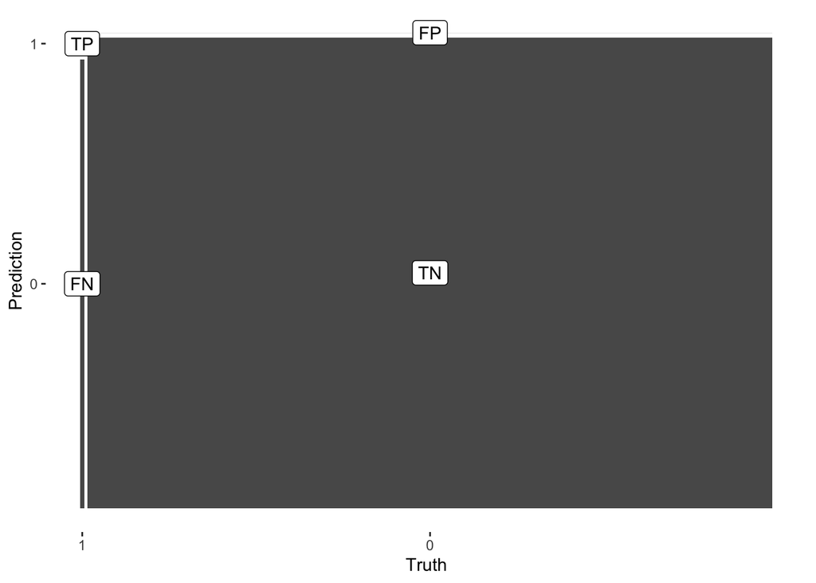

```r
log_pred %>%
  conf_mat(is_fraud, .pred_class) %>%
  autoplot(type = "mosaic") +
  geom_label(aes(
      x = (xmax + xmin) / 2,
      y = (ymax + ymin) / 2,
      label = c("TP", "FN", "FP", "TN")))
```

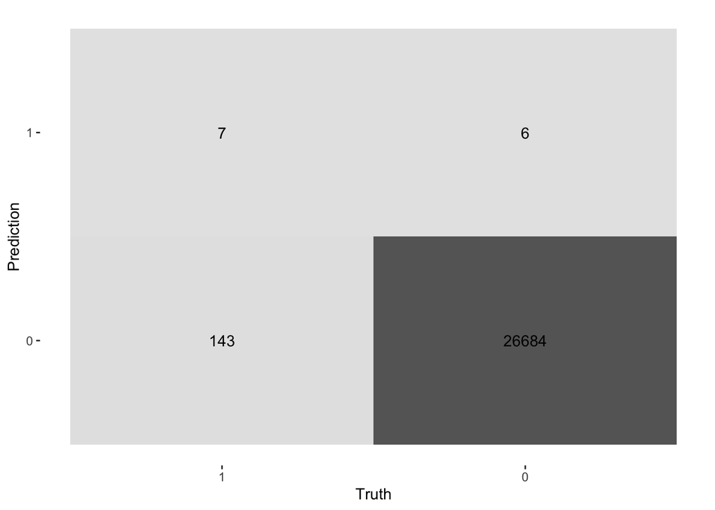

```r
log_pred %>%
  conf_mat(is_fraud, .pred_class) %>%
  autoplot(type = "heatmap")
```

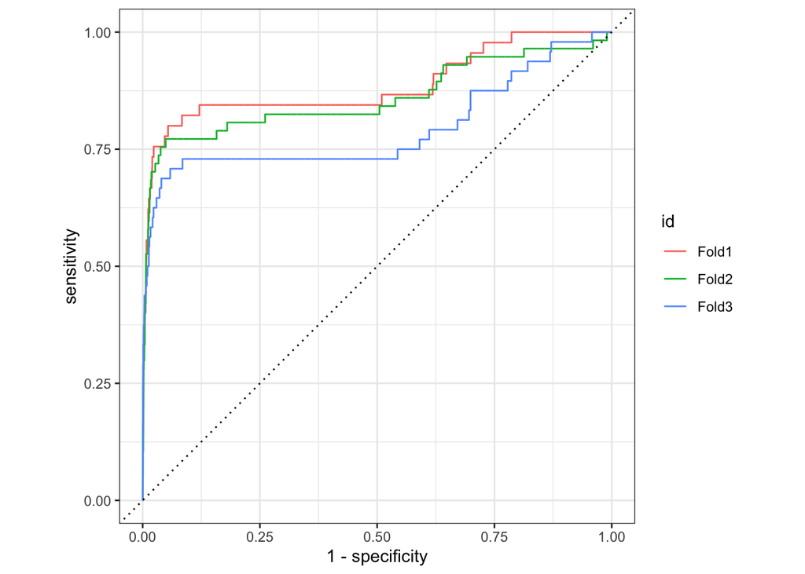

```r
## ROC Curve

log_pred %>%
  group_by(id) %>% # id contains our folds
  roc_curve(is_fraud, .pred_1) %>%
  autoplot()
```

```r
## Decision Tree results
tic()
tree_res <-
  tree_wflow %>%
  fit_resamples(
    resamples = cv_folds,
    metrics = metric_set(
      recall, precision, f_meas,
      accuracy, kap,
      roc_auc, sens, spec),
    control = control_resamples(save_pred = TRUE)
    )
time <- toc()
```

```
## 8.849 sec elapsed
```

```r
tree_time <- time[[4]]

## Random Forest

tic()
rf_res <-
  rf_wflow %>%
  fit_resamples(
    resamples = cv_folds,
    metrics = metric_set(
      recall, precision, f_meas,
      accuracy, kap,
      roc_auc, sens, spec),
    control = control_resamples(save_pred = TRUE)
    )
time <- toc()
```

```
## 15.235 sec elapsed
```

```r
rf_time <- time[[4]]

## Boosted tree - XGBoost

tic()
xgb_res <-
  xgb_wflow %>%
  fit_resamples(
    resamples = cv_folds,
    metrics = metric_set(
      recall, precision, f_meas,
      accuracy, kap,
      roc_auc, sens, spec),
    control = control_resamples(save_pred = TRUE)
    )
time <- toc()
```

```
## 2.15 sec elapsed
```

```r
xgb_time <- time[[4]]

## K-nearest neighbour

tic()
knn_res <-
  knn_wflow %>%
  fit_resamples(
    resamples = cv_folds,
    metrics = metric_set(
      recall, precision, f_meas,
      accuracy, kap,
      roc_auc, sens, spec),
    control = control_resamples(save_pred = TRUE)
    )
time <- toc()
```

```
## 82.145 sec elapsed
```

```r
knn_time <- time[[4]]
```

## 2.13 Compare models

```r
## Model Comparison

log_metrics <-
  log_res %>%
  collect_metrics(summarise = TRUE) %>%
  # add the name of the model to every row
  mutate(model = "Logistic Regression",
         time = log_time)

# Show average performance over all folds (note that we use log_res):
log_res %>%  collect_metrics(summarize = TRUE)
```

```
## # A tibble: 8 × 6
##   .metric   .estimator   mean     n   std_err .config
##   <chr>     <chr>       <dbl> <int>     <dbl> <chr>
## 1 accuracy  binary     0.994      3 0.000467  Preprocessor1_Model1
## 2 f_meas    binary     0.0857     3 0.0333    Preprocessor1_Model1
## 3 kap       binary     0.0849     3 0.0332    Preprocessor1_Model1
## 4 precision binary     0.511      3 0.146     Preprocessor1_Model1
## 5 recall    binary     0.0469     3 0.0186    Preprocessor1_Model1
## 6 roc_auc   binary     0.846      3 0.0281    Preprocessor1_Model1
## 7 sens      binary     0.0469     3 0.0186    Preprocessor1_Model1
## 8 spec      binary     1.00       3 0.0000650 Preprocessor1_Model1
```

```r
# Show performance for every single fold:
log_res %>%  collect_metrics(summarize = FALSE)
```

```
## # A tibble: 24 × 5
##    id    .metric   .estimator .estimate .config
##    <chr> <chr>     <chr>          <dbl> <chr>
##  1 Fold1 recall    binary        0.0222 Preprocessor1_Model1
##  2 Fold1 precision binary        0.333  Preprocessor1_Model1
##  3 Fold1 f_meas    binary        0.0417 Preprocessor1_Model1
##  4 Fold1 accuracy  binary        0.995  Preprocessor1_Model1
##  5 Fold1 kap       binary        0.0411 Preprocessor1_Model1
##  6 Fold1 sens      binary        0.0222 Preprocessor1_Model1
##  7 Fold1 spec      binary        1.00   Preprocessor1_Model1
##  8 Fold1 roc_auc   binary        0.886  Preprocessor1_Model1
##  9 Fold2 recall    binary        0.0351 Preprocessor1_Model1
## 10 Fold2 precision binary        0.4    Preprocessor1_Model1
## # ℹ 14 more rows
```

```r
## `collect_predictions()` and get confusion matrix{.smaller}

log_pred <- log_res %>% collect_predictions()

log_pred %>%  conf_mat(is_fraud, .pred_class)
```

```
##           Truth
## Prediction     1     0
##          1     7     6
##          0   143 26684
```

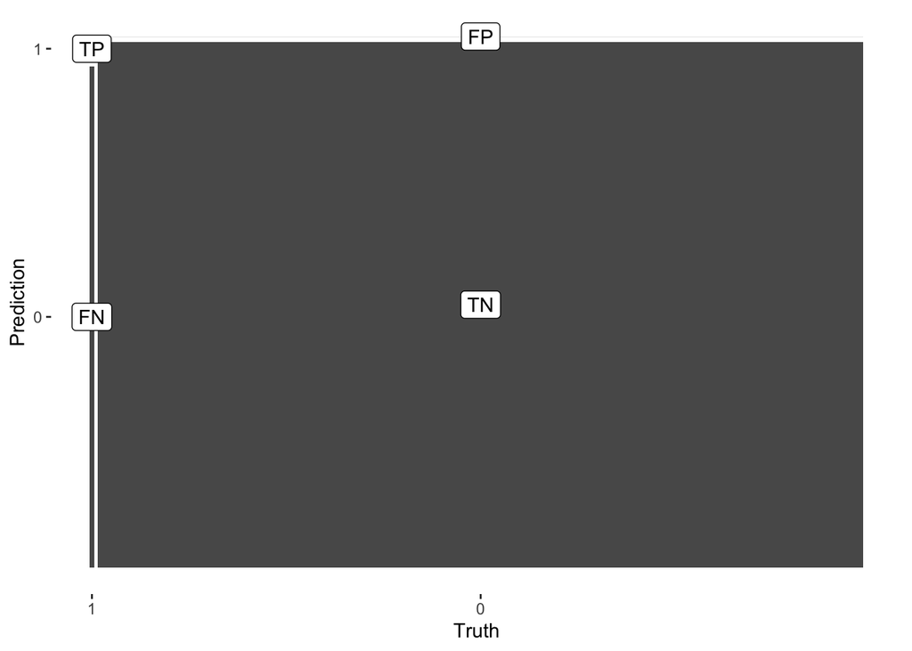

```r
log_pred %>%
  conf_mat(is_fraud, .pred_class) %>%
  autoplot(type = "mosaic") +
  geom_label(aes(
      x = (xmax + xmin) / 2,
      y = (ymax + ymin) / 2,
      label = c("TP", "FN", "FP", "TN")))
```

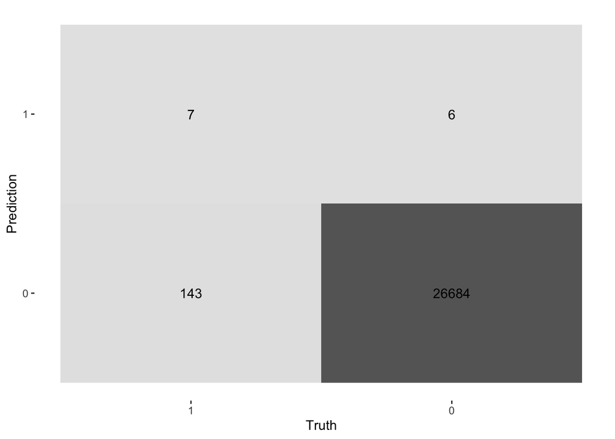

```r
log_pred %>%
  conf_mat(is_fraud, .pred_class) %>%
  autoplot(type = "heatmap")
```

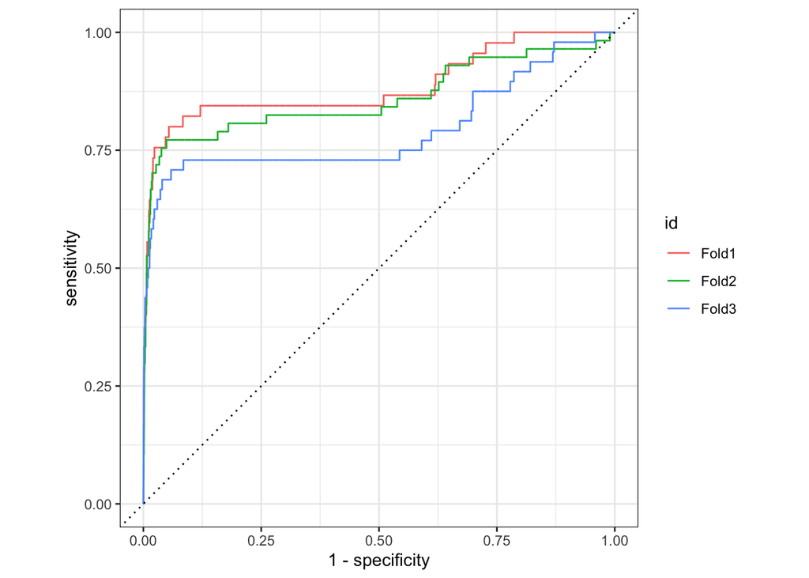

```r
## ROC Curve

log_pred %>%
  group_by(id) %>% # id contains our folds
  roc_curve(is_fraud, .pred_1) %>%
  autoplot()
```

```r
## Decision Tree results

tree_res %>%  collect_metrics(summarize = TRUE)
```

```
## # A tibble: 8 × 6
##   .metric   .estimator  mean     n  std_err .config
##   <chr>     <chr>      <dbl> <int>    <dbl> <chr>
## 1 accuracy  binary     0.998     3 0.000476 Preprocessor1_Model1
## 2 f_meas    binary     0.749     3 0.0481   Preprocessor1_Model1
## 3 kap       binary     0.748     3 0.0483   Preprocessor1_Model1
## 4 precision binary     0.852     3 0.0374   Preprocessor1_Model1
## 5 recall    binary     0.670     3 0.0571   Preprocessor1_Model1
## 6 roc_auc   binary     0.844     3 0.0433   Preprocessor1_Model1
## 7 sens      binary     0.670     3 0.0571   Preprocessor1_Model1
## 8 spec      binary     0.999     3 0.000135 Preprocessor1_Model1
```

```r
## Random Forest

rf_res %>%  collect_metrics(summarize = TRUE)
```

```
## # A tibble: 8 × 6
##   .metric   .estimator  mean     n   std_err .config
##   <chr>     <chr>      <dbl> <int>     <dbl> <chr>
## 1 accuracy  binary     0.995     3 0.000501  Preprocessor1_Model1
## 2 f_meas    binary     0.241     3 0.0662    Preprocessor1_Model1
## 3 kap       binary     0.240     3 0.0661    Preprocessor1_Model1
## 4 precision binary     0.952     3 0.0476    Preprocessor1_Model1
## 5 recall    binary     0.141     3 0.0443    Preprocessor1_Model1
## 6 roc_auc   binary     0.952     3 0.00314   Preprocessor1_Model1
## 7 sens      binary     0.141     3 0.0443    Preprocessor1_Model1
## 8 spec      binary     1.00      3 0.0000375 Preprocessor1_Model1
```

```r
## Boosted tree - XGBoost

xgb_res %>% collect_metrics(summarize = TRUE)
```

```
## # A tibble: 8 × 6
##   .metric   .estimator  mean     n  std_err .config
##   <chr>     <chr>      <dbl> <int>    <dbl> <chr>
## 1 accuracy  binary     0.998     3 0.000453 Preprocessor1_Model1
## 2 f_meas    binary     0.745     3 0.0419   Preprocessor1_Model1
## 3 kap       binary     0.744     3 0.0421   Preprocessor1_Model1
## 4 precision binary     0.877     3 0.0669   Preprocessor1_Model1
## 5 recall    binary     0.649     3 0.0321   Preprocessor1_Model1
## 6 roc_auc   binary     0.962     3 0.0111   Preprocessor1_Model1
## 7 sens      binary     0.649     3 0.0321   Preprocessor1_Model1
## 8 spec      binary     0.999     3 0.000300 Preprocessor1_Model1
```

```r
## K-nearest neighbour

knn_res %>% collect_metrics(summarize = TRUE)
```

```
## # A tibble: 8 × 6
##   .metric   .estimator   mean     n  std_err .config
##   <chr>     <chr>       <dbl> <int>    <dbl> <chr>
## 1 accuracy  binary     0.993      3 0.000430 Preprocessor1_Model1
## 2 f_meas    binary     0.0470     3 0.00715  Preprocessor1_Model1
## 3 kap       binary     0.0440     3 0.00693  Preprocessor1_Model1
## 4 precision binary     0.0837     3 0.0123   Preprocessor1_Model1
## 5 recall    binary     0.0330     3 0.00571  Preprocessor1_Model1
## 6 roc_auc   binary     0.552      3 0.00300  Preprocessor1_Model1
## 7 sens      binary     0.0330     3 0.00571  Preprocessor1_Model1
## 8 spec      binary     0.998      3 0.000234 Preprocessor1_Model1
```

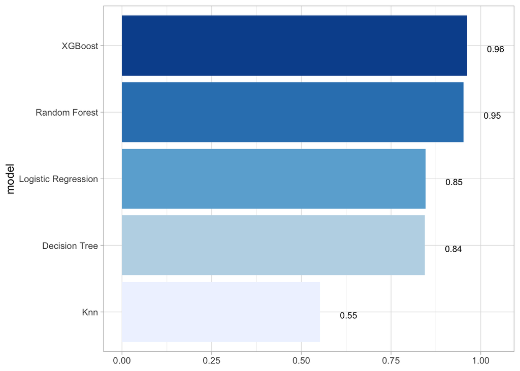

```r
## Model Comparison

log_metrics <-
  log_res %>%
  collect_metrics(summarise = TRUE) %>%
  # add the name of the model to every row
  mutate(model = "Logistic Regression",
         time = log_time)

tree_metrics <-
  tree_res %>%
  collect_metrics(summarise = TRUE) %>%
  mutate(model = "Decision Tree",
         time = tree_time)

rf_metrics <-
  rf_res %>%
  collect_metrics(summarise = TRUE) %>%
  mutate(model = "Random Forest",
         time = rf_time)

xgb_metrics <-
  xgb_res %>%
  collect_metrics(summarise = TRUE) %>%
  mutate(model = "XGBoost",
         time = xgb_time)

knn_metrics <-
  knn_res %>%
  collect_metrics(summarise = TRUE) %>%
  mutate(model = "Knn",
         time = knn_time)

# create dataframe with all models
model_compare <- bind_rows(log_metrics,
                           tree_metrics,
                           rf_metrics,
                           xgb_metrics,
                           knn_metrics)

#Pivot wider to create barplot
  model_comp <- model_compare %>%
  select(model, .metric, mean, std_err) %>%
  pivot_wider(names_from = .metric, values_from = c(mean, std_err))

# show mean are under the curve (ROC-AUC) for every model
model_comp %>%
  arrange(mean_roc_auc) %>%
  mutate(model = fct_reorder(model, mean_roc_auc)) %>% # order results
  ggplot(aes(model, mean_roc_auc, fill=model)) +
  geom_col() +
  coord_flip() +
  scale_fill_brewer(palette = "Blues") +
   geom_text(
     size = 3,
     aes(label = round(mean_roc_auc, 2),
         y = mean_roc_auc + 0.08),
     vjust = 1
  )+
  theme_light()+
  theme(legend.position = "none")+
  labs(y = NULL)
```

## 2.14 Which metric to use

This is a highly imbalanced data set, as roughly 99.5% of all transactions are ok, and it’s only 0.5% of transactions that are fraudulent. A `naive` model, which classifies everything as ok and not-fraud, would have an accuracy of 99.5%, but what about the sensitivity, specificity, the AUC, etc?

## 2.15 `last_fit()`

```r
## `last_fit()` on is_fraud set

# - `last_fit()`  fits a model to the whole training data and evaluates it on the is_fraud set.
# - provide the workflow object of the best model as well as the data split object (not the training data).


last_fit_xgb <- last_fit(xgb_wflow,
                        split = data_split,
                        metrics = metric_set(
                          accuracy, f_meas, kap, precision,
                          recall, roc_auc, sens, spec))

last_fit_xgb %>% collect_metrics(summarize = TRUE)
```

```
## # A tibble: 8 × 4
##   .metric   .estimator .estimate .config
##   <chr>     <chr>          <dbl> <chr>
## 1 accuracy  binary         0.997 Preprocessor1_Model1
## 2 f_meas    binary         0.588 Preprocessor1_Model1
## 3 kap       binary         0.587 Preprocessor1_Model1
## 4 precision binary         0.833 Preprocessor1_Model1
## 5 recall    binary         0.455 Preprocessor1_Model1
## 6 sens      binary         0.455 Preprocessor1_Model1
## 7 spec      binary         1.00  Preprocessor1_Model1
## 8 roc_auc   binary         0.967 Preprocessor1_Model1
```

```r
#Compare to training
xgb_res %>% collect_metrics(summarize = TRUE)
```

```
## # A tibble: 8 × 6
##   .metric   .estimator  mean     n  std_err .config
##   <chr>     <chr>      <dbl> <int>    <dbl> <chr>
## 1 accuracy  binary     0.998     3 0.000453 Preprocessor1_Model1
## 2 f_meas    binary     0.745     3 0.0419   Preprocessor1_Model1
## 3 kap       binary     0.744     3 0.0421   Preprocessor1_Model1
## 4 precision binary     0.877     3 0.0669   Preprocessor1_Model1
## 5 recall    binary     0.649     3 0.0321   Preprocessor1_Model1
## 6 roc_auc   binary     0.962     3 0.0111   Preprocessor1_Model1
## 7 sens      binary     0.649     3 0.0321   Preprocessor1_Model1
## 8 spec      binary     0.999     3 0.000300 Preprocessor1_Model1
```

## 2.16 Get variable importance using `vip` package

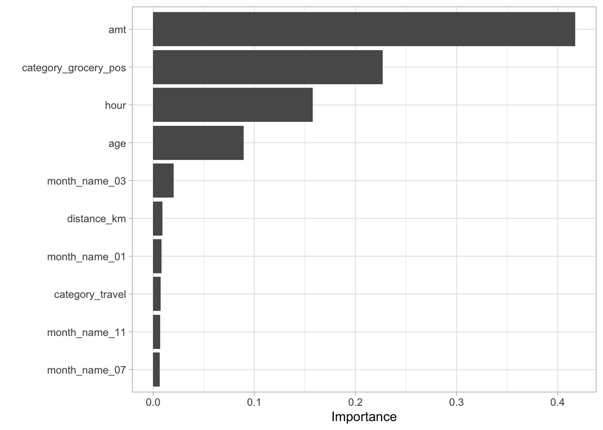

```r
library(vip)

last_fit_xgb %>%
  pluck(".workflow", 1) %>%
  extract_fit_parsnip() %>%
  vip(num_features = 10) +
  theme_light()
```